# How Does Climate Change Exacerbate Toxin Accumulation in Southern Resident Killer Whale Populations?

Elisa Herter

# 1 Introduction

Southern Resident Killer Whales (SRKWs; *Orcinus orca*) are a critically endangered population of approximately 73 individuals restricted to the inland waters of the Pacific Northwest. Despite decades of federal protection under the U.S. Endangered Species Act and Canada’s Species at Risk Act, the population has continued to decline, with fewer than 74 individuals as of 2024. The three primary stressors driving population decline are insufficient Chinook salmon prey, elevated persistent organic pollutants (POPs), and vessel noise (Williams et al., 2024). Among these, the interaction between prey scarcity and contaminant burden has received growing scientific attention, yet remains poorly captured by existing models.

Polychlorinated biphenyls (PCBs) are lipophilic organochlorines that accumulate up the food chain and reach peak concentrations in apex predators. Male SRKWs carry average blubber PCB loads of ~45,000 ng/g lipid weight, levels that exceed health-effects thresholds documented in harbor seals (Mongillo et al., 2016). PCBs impair reproductive function, suppress immune response, and can cause endocrine disruption, neurological damage, and cancer. When whales enter negative energy balance due to prey scarcity, blubber lipid reserves are mobilized, releasing stored PCBs directly into circulation and dramatically amplifying internal exposure (Marine Mammal Commission, 2020; Desforges et al., 2018).

Climate change operates as a force multiplier on this mechanism. Chinook salmon, the main prey of SRKWs, are highly vulnerable to ocean warming. Life-cycle models project that Snake River spring/summer Chinook populations will decline rapidly under RCP 4.5 and RCP 8.5 scenarios, driven by rising sea surface temperatures and degraded freshwater habitat, with the largest populations facing high extinction risk by the 2060s (Crozier et al., 2021). This prey decline intersects with the blubber-mobilization pathway in a critical way: when whales experience negative energy balance during periods of low prey availability, they catabolize lipid reserves to meet metabolic demands, releasing sequestered PCBs directly into circulation (Desforges et al., 2018). Climate change therefore operates simultaneously on both sides of the toxin-burden equation, reducing dietary uptake of contaminants while accelerating mobilization of those already stored in blubber. The net result is amplified internal exposure that scales with the severity of climate-driven prey decline, yet this interaction has not been formally quantified at the population level.

The central research question of this project is: **Does climate-driven Chinook salmon decline accelerate Southern Resident Killer Whale population collapse by amplifying internal PCB exposure through blubber mobilization, and if so, at what rate of prey decline does this toxin feedback become the decisive driver of extinction risk?** This question does not have an obvious answer because it depends on two interacting uncertainties: (1) how frequently warming-induced prey shortfalls are severe enough to trigger blubber catabolism, and (2) how close current tissue PCB concentrations already are to published biological thresholds for reproductive suppression ($T_f = 40$ mg/kg) and immune impairment ($T_s = 17$ mg/kg). A population whose reproductive females are far below $T_f$ might tolerate decades of moderate prey decline before mobilization becomes consequential; one already near threshold could tip into an extinction spiral rapidly. I answer this question with a stage-structured stochastic population model that couples climate-forced prey dynamics to a mechanistic toxin sub-model, described in the following sections.

# 2 Model Description

## 2.1 Stage-Structured Demographic Framework

The population is modeled as a stage-structured matrix model with $n = 4$ biologically distinct life stages: (1) calves (0–2 yr), (2) juveniles (2–10 yr), (3) reproductive females (10–42 yr), and (4) post-reproductive individuals (>42 yr). This staging reflects SRKW life history as documented in long-term photo-identification records (Olesiuk et al., 1990; Ford et al., 2010). The population state vector at time $t$ is:

$$\mathbf{N}(t) = [N_1(t),\ N_2(t),\
N_3(t),\ N_4(t)]^\top$$

Population projection equation:

$$\mathbf{N}(t+1) = \mathbf{A}(t) \cdot
\mathbf{N}(t)$$

where $\mathbf{A}(t)$ is the annual projection matrix containing survival probabilities ($\sigma_i$), stage-transition probabilities ($\gamma_i$), and fecundity ($F_i$). Environmental stochasticity is introduced through annual prey availability $P(t)$, drawn from a log-normal distribution with a climate-driven secular trend:

$$\log P(t) \sim
\text{Normal}\!\left(\mu_P + \beta_{\text{clim}} \cdot t,\
\sigma_P^2\right)$$

where $\beta_{\text{clim}} < 0$ is the per-year rate of prey decline parameterized from projected Chinook salmon escapement under IPCC SSP (Intergovernmental Panel on Climate Change Shared Socioeconomic Pathways) scenarios, and $\sigma_P$ captures interannual variability. The model is stochastic (random prey draws each year), discrete-time (annual time steps), and density-independent (appropriate for a critically small population well below carrying capacity).

## 2.2 Toxin Sub-Model

Each life stage $i$ carries a PCB burden $T_i(t)$ (mg/kg lipid weight). Three processes update toxin loads annually:

**2. Fasting-driven blubber mobilization** — when prey falls below threshold $P_{\min}$, whales draw on lipid reserves, releasing stored PCBs into circulation (Marine Mammal Commission, 2020):

$$\Delta T_{\text{mob},i} = \delta \cdot
\max(0,\ P_{\min} - P(t)) \cdot T_i(t)$$

**3. Maternal transfer** — a fraction $\rho$ of a reproductive female’s PCB burden is passed to her calf through gestation and lactation (Mongillo et al., 2016):

$$T_{\text{calf}}(0) = \rho \cdot
T_3(t_{\text{birth}}); \qquad T_3 \;\to\; T_3 \cdot (1 -
\rho)$$

## 2.3 Toxin–Vital Rate Coupling

Toxin loads feed back into matrix entries via logistic dose-response functions, justified by well-documented nonlinearity of PCB effects in cetaceans (scientific name for the group of marine mammals that includes all whales, dolphins, and porpoises). Fecundity of reproductive females is suppressed above threshold $T_f$:

$$F_3(t) = F_{3,\max} \cdot \frac{1}{1 +
\exp\!\left(\kappa_f \cdot (T_3(t) - T_f)\right)}$$

Calf and juvenile survival are reduced above immune-impairment threshold $T_s$:

$$\sigma_i(t) = \sigma_{i,\max} \cdot
\frac{1}{1 + \exp\!\left(\kappa_s \cdot (T_i(t) -
T_s)\right)}$$

The logistic form produces smooth transitions between unimpaired and impaired vital rates, avoiding discontinuities while remaining biologically interpretable. Threshold values are anchored to published SRKW ecotoxicology data: $T_f \approx 40$ mg/kg l.w. for reproductive suppression and $T_s \approx 17$ mg/kg l.w. for immune impairment (Desforges et al., 2018; Mongillo et al., 2016).

## 2.4 Parameters and Variables

**Table 1.** Model parameters, values, and sources.

[output not shown]

## 2.5 Model Justification

A stage-structured matrix model is appropriate for three reasons. - First, SRKWs have four biologically meaningful life stages with well-characterized vital rates from 50+ years of individual-level monitoring, a resolution that matches the data without requiring the unidentifiable parameters of an individual-based model. - Second, the toxin sub-model is mechanistically grounded: PCB pharmacokinetics in cetaceans are dominated by lipid dynamics, and the fasting-mobilization pathway has been empirically documented in multiple marine mammal species (Marine Mammal Commission, 2020). - Third, the logistic coupling of toxin to vital rates introduces biologically realistic nonlinearity with only two estimable parameters per function. The model is parsimonious, transparent, and directly interrogates the climate–toxin–demography feedback at the center of the research question.

# 3 Methods

**Step 1** — Vital rates ($\sigma_i$, $F_i$, $\gamma_i$) are compiled from published SRKW demographic studies. PCB thresholds and initial tissue burdens are drawn from NOAA Technical Memorandum NMFS-NWFSC-135 (Mongillo et al., 2016) and Desforges et al. (2018). Climate prey-decline rates ($\beta_{\text{clim}}$) are derived from projected Chinook escapement under IPCC SSP2-4.5 and SSP5-8.5 scenarios, calibrated to Crozier et al. (2021) life-cycle model outputs.

# 4 Model/Methods Figure

### 4.0.1 Figure 1: Conceptual Model

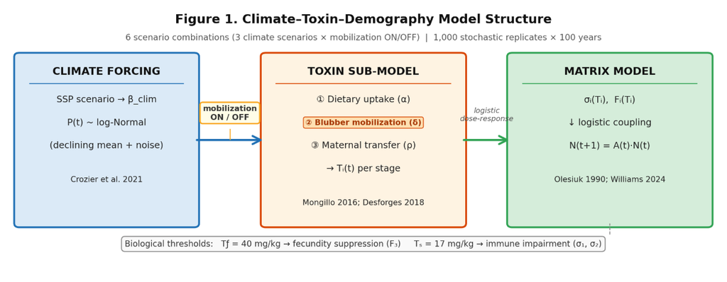

This diagram shows the causal pathway through which climate change may accelerate SRKW population collapse. The critical link is the fasting-mobilization arrow connecting the prey module to the toxin sub-model: when climate-driven prey scarcity forces blubber catabolism, stored PCBs are released into circulation, potentially pushing reproductive female loads past the threshold $T_f = 40$ mg/kg that suppresses fecundity. Whether this pathway meaningfully elevates extinction risk above prey loss alone is the core question; the on/off toggle on that arrow is the experimental lever for answering it. Climate forcing (left) drives stochastic prey availability under three IPCC emissions scenarios. The toxin sub-model (center) tracks PCB burden via dietary uptake, blubber mobilization, and maternal transfer. Logistic dose-response functions (right) translate stage-specific toxin loads into suppressed survival and fecundity within the demographic matrix. 1,000 stochastic replicates × 100 years per scenario.

# 5 Anticipated Results

### 5.0.1 Figure 2: Population Trajectories Under Climate Scenarios

This is the primary result figure, it directly answers the research question by showing whether the toxin-feedback pathway meaningfully increases extinction probability above what prey loss alone would produce. The side-by-side mobilization-on vs. off panels isolate the pathway’s contribution: if the on-panels show substantially higher quasi-extinction probability or faster median collapse under SSP2-4.5 or SSP5-8.5, it confirms the blubber mobilization pathway is a decisive amplifier of climate-driven collapse, not a secondary effect.

**Type:** Line plot with ribbon envelopes, two-panel layout (mobilization on / mobilization off).

**Axes:** x = year (0–100); y = total SRKW population size ($N$).  
**Data:** Median trajectory and 50%/95% envelopes from 1,000 replicates; three colored lines per panel for baseline, SSP2-4.5, and SSP5-8.5. A horizontal dashed line marks the quasi-extinction threshold ($N_\text{females} = 10$).

**Expected outcome:** Under mobilization-on, climate scenarios produce increasingly depressed median trajectories, elevated quasi-extinction probabilities, and wider uncertainty envelopes relative to mobilization-off. A >15 percentage-point difference in quasi-extinction probability between on/off panels under SSP5-8.5 would constitute strong evidence that the toxin feedback, not prey loss alone, is the decisive driver of collapse risk at severe warming rates.

### 5.0.2 Figure 3: Stage-Specific PCB Trajectories and Threshold Crossing

This is the mechanistic bridge between climate forcing and demographic outcome. Figure 2 shows *whether* the mobilization pathway elevates extinction risk; Figure 3 shows *how* — by tracing the PCB accumulation trajectories that trigger the logistic dose-response suppression of fecundity ($F_3$) and calf survival ($\sigma_1$). The critical diagnostic is whether reproductive female loads cross $T_f = 40$ mg/kg under climate forcing but remain sub-threshold without it, which would confirm that blubber mobilization — not baseline dietary uptake — is the mechanism driving the demographic divergence seen in Figure 2.

**Type:** Faceted line plot (one panel per life stage).

**Axes:** x = year (0–100); y = mean PCB concentration (mg/kg lipid weight).

**Data:** Mean across replicates for each climate scenario; horizontal dashed reference lines at $T_s = 17$ mg/kg (immune impairment) and $T_f = 40$ mg/kg (reproductive suppression).

**Expected outcome:** Under the severe scenario, reproductive females cross $T_f$ within ~70 years due to compounding fasting-mobilization events; calves show elevated loads reflecting maternal transfer from increasingly burdened mothers. Baseline loads remain sub-threshold throughout. Together with Figure 2, this establishes the rate of prey decline at which the toxin feedback transitions from secondary to decisive — directly answering the research question (Williams et al. 2024; Desforges et al. 2018).